# Phan tich hoi tu GRDP/nguoi

ca nuoc - 63 tinh/thanh

Vo Thanh Danh

# 1 Load the Data

```r
# Goi dataframe
grdp <- import(here("gso", "grdp_vn.xlsx"))
```

# 2 Phân tích tương quan giữa mean va độ lệch chuẩn của biến grdp để xác định xu hướng hội tụ hay phân kỳ

A. VỀ HỘI TỤ HAY PHÂN KỲ:

• Hội tụ thu nhập: Nếu một quốc gia hoặc khu vực có mean thấp nhưng độ lệch chuẩn cao, có thể chỉ ra rằng thu nhập bình quân đầu người của quốc gia đó đang có xu hướng hội tụ về mức thu nhập trung bình toàn cầu hoặc khu vực, nhưng mức độ phân hóa thu nhập vẫn còn lớn. Khi có sự giảm bớt sự phân hóa (độ lệch chuẩn giảm), đó có thể là dấu hiệu của hội tụ kinh tế.

• Phân kỳ thu nhập: Ngược lại, nếu mean cao và độ lệch chuẩn cũng cao, có thể chỉ ra rằng mức thu nhập ở quốc gia đó đang phân tán và có sự phân kỳ (sự khác biệt về mức thu nhập giữa các khu vực hoặc quốc gia ngày càng lớn).

B. VỀ MỐI QUAN HỆ GIỮA Mean VÀ Độ lệch chuẩn:

1. Nếu mean cao nhưng độ lệch chuẩn cũng cao, điều này có thể cho thấy một nhóm có thu nhập trung bình cao, nhưng sự phân hóa thu nhập cũng rất lớn. Ví dụ: có tỉnh có grdp/người cao và cũng có nhiều tỉnh có grdp/người thấp.
2. Nếu mean cao nhưng độ lệch chuẩn thấp, có thể nhóm này có grdp/người cao và khá đồng đều (không có sự phân hóa lớn).
3. Nếu mean thấp và độ lệch chuẩn cũng thấp, có thể cho thấy grdp/người trung bình của nhóm này thấp và đồng đều.
4. Nếu mean thấp nhưng độ lệch chuẩn cao, có thể có sự phân hóa grdp/người rõ rệt trong một nhóm có grdp/người thấp.

```r
pacman::p_load(dplyr, gglot2)
```

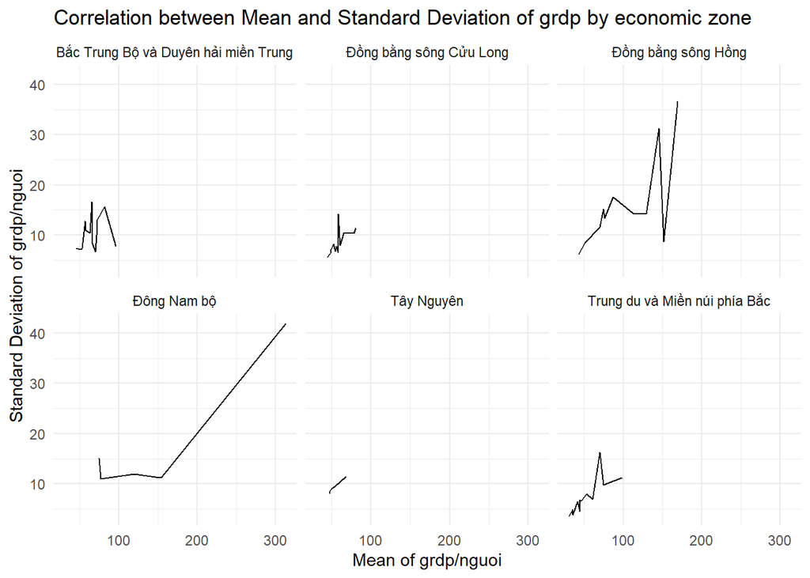

```r
ggplot(data = grdp)+
  geom_line(
    mapping = aes(x = mean_grdp, y = sd_grdp, fill = zone),
    width = 1, fill = "darkred")+
  facet_wrap(~ zone) +
  theme_minimal()+ # other specification for the geom
  labs(title = "Correlation between Mean and Standard Deviation of grdp by economic zone",
       x = "Mean of grdp/nguoi",
       y = "Standard Deviation of grdp/nguoi",
       color = "zone") +
  theme_minimal()
```

# 3 Phân tích hội tụ beta

## 3.1 Beta convergence: 2018-2023 period

### 3.1.1 OLS

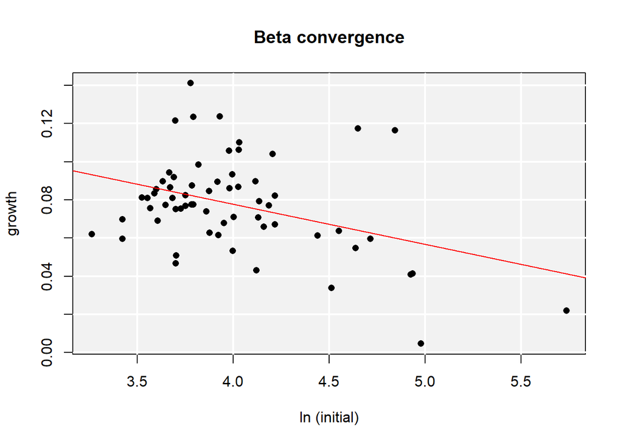

```r
betaconv_ols <- betaconv.ols (grdp$y2018,
              2018,
              grdp$y2023,
              2023,
              conditions = NULL,
              beta.plot = TRUE,
              beta.plotLine = TRUE,
              beta.plotLineCol = "red",
              beta.plotX = "ln (initial)",
              beta.plotY = "growth",
              beta.plotTitle = "Beta convergence",
              beta.bgrid = TRUE,
              beta.bgridType = "solid",
              # output.results = TRUE
              )
```

```r
betaconv_ols
```

```
## $regdata
##    ln_initial ln_growth
## 1       4.715  0.059542
## 2       4.549  0.063787
## 3       4.976  0.004639
## 4       4.843  0.116556
## 5       4.114  0.089623
## 6       4.648  0.117536
## 7       4.203  0.103951
## 8       3.689  0.091801
## 9       4.031  0.110037
## 10      3.552  0.080902
## 11      3.995  0.093355
## 12      3.262  0.062082
## 13      3.421  0.059488
```

[output cut: 65 more lines]

#### 3.1.1.1 Đò thị: Linear beta-convergence regression

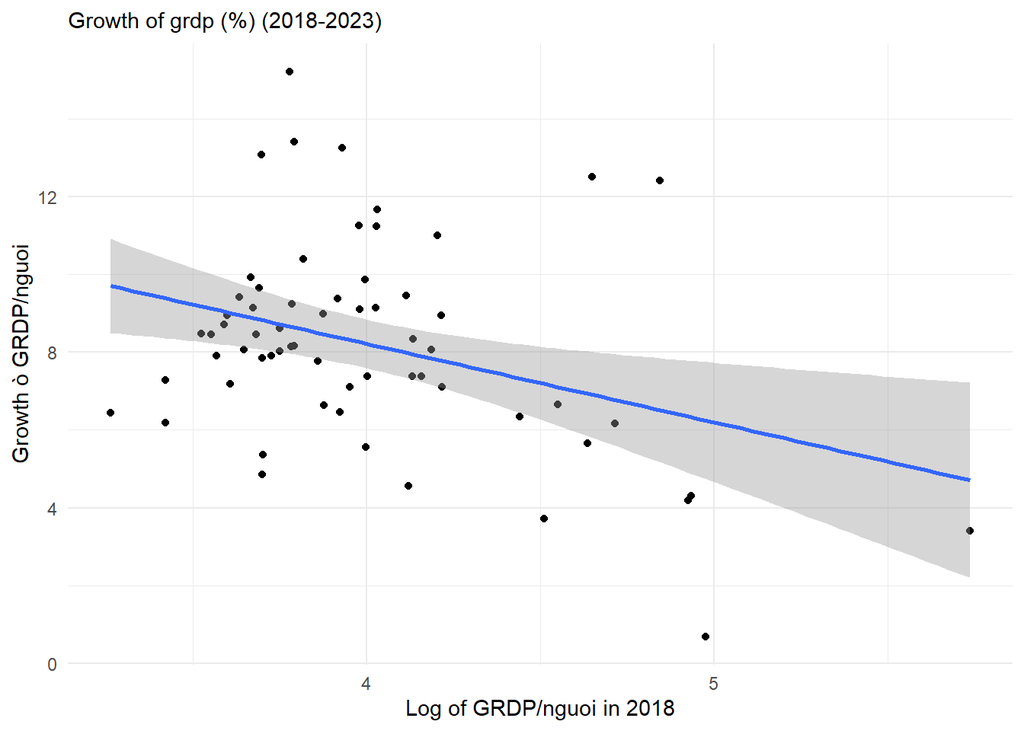

```r
# Create a new column ln_initial = log(y2018)
ln_initial <- grdp %>%
  mutate(ln_initial = log(y2018))

betaconv_ols[["regdata"]] %>%
  ggplot(aes(x = ln_initial, y = grdp$growth)) +
  geom_point() +
  geom_smooth(method = lm) +
theme_minimal() +
labs(subtitle = "Growth of grdp (%) (2018-2023)",
   x = "Log of GRDP/nguoi in 2018",
   y = "Growth ò GRDP/nguoi")
```

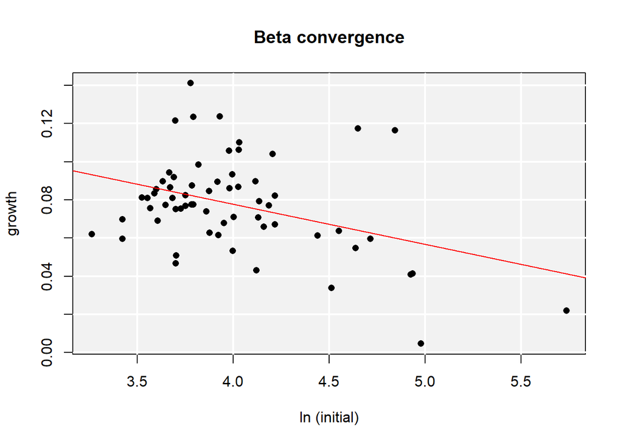

```r
betaconv_nls <- betaconv.ols (grdp$y2018,
              2018,
              grdp$y2023,
              2023,
              conditions = NULL,
              beta.plot = TRUE,
              beta.plotLine = TRUE,
              beta.plotLineCol = "red",
              beta.plotX = "ln (initial)",
              beta.plotY = "growth",
              beta.plotTitle = "Beta convergence",
              beta.bgrid = TRUE,
              beta.bgridType = "solid",
              # output.results = TRUE
              )
```

```r
betaconv_nls
```

```
## $regdata
##    ln_initial ln_growth
## 1       4.715  0.059542
## 2       4.549  0.063787
## 3       4.976  0.004639
## 4       4.843  0.116556
## 5       4.114  0.089623
## 6       4.648  0.117536
## 7       4.203  0.103951
## 8       3.689  0.091801
## 9       4.031  0.110037
## 10      3.552  0.080902
## 11      3.995  0.093355
## 12      3.262  0.062082
## 13      3.421  0.059488
```

[output cut: 65 more lines]

#### 3.1.2.1 Đò thị: non-linear beta-convergence regression

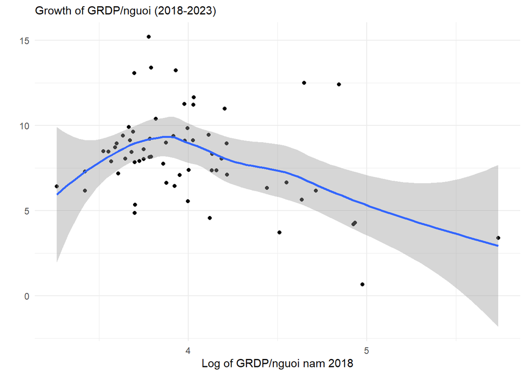

```r
betaconv_nls[["regdata"]] %>%
  ggplot(aes(x = ln_initial, y = grdp$growth)) +
  geom_point() +
  geom_smooth() +
  theme_minimal() +
  labs(subtitle = "Growth of GRDP/nguoi (2018-2023)",
       x = "Log of GRDP/nguoi nam 2018",
       y = "")
```

# 4 Phân tích hội tụ sigma

## 4.1 Sigma convergence for two periods (ANOVA): 2018 and 2023

```r
sigma_anova_sd_log <- sigmaconv(
          grdp$y2018,
          2018,
          grdp$y2023,
          2023,
          sigma.measure = "sd",
          sigma.log = TRUE
          )
sigma_anova_sd_log
```

```
## $sigmaconv
##          Estimate F value df1 df2 Pr (>F)
## SD 2018     0.448      NA  NA  NA      NA
## SD 2023     0.417      NA  NA  NA      NA
## Quotient    1.074   1.154  62  62  0.5737
```

## 4.2 Sigma convergence for multiple periods (Trend regression)

```r
sigma_trend_sd_log <- sigmaconv.t(
   grdp$y2018,
      2018,
   grdp[3:7],
      2023,
 sigma.measure = "sd",
  sigma.log = TRUE)
sigma_trend_sd_log
```

```
## $sigma.trend
##       years sigma.years
## gdp1   2018      0.4480
## y2019  2019      0.4427
## y2020  2020      0.4191
## y2021  2021      0.4281
## y2022  2022      0.4341
## y2023  2023      0.4170
##
## $estimates
##            Estimate Std. Error t value Pr(>|t|)
## Intercept 10.361990   4.571313   2.267  0.08604
## Time      -0.004915   0.002262  -2.172  0.09556
##
## $modelstat
##           Estimate F value df 1 df 2 Pr (>F)
## R-Squared   0.5412   4.719    1    4 0.09556
```

## 4.3 Đồ thị: Linear trend regression

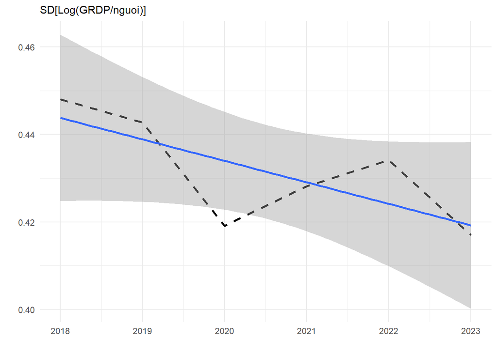

```r
sigma_trend_sd_log[["sigma.trend"]] %>%
  ggplot(aes(x = years, y = sigma.years)) +
  geom_line(size=1, linetype = "dashed") +
  geom_smooth(method = lm) +
  theme_minimal() +
  labs(subtitle = "SD[Log(GRDP/nguoi)]",
       x = "",
       y = "")
```

## 4.4 Đồ thị: non-linear trend regression

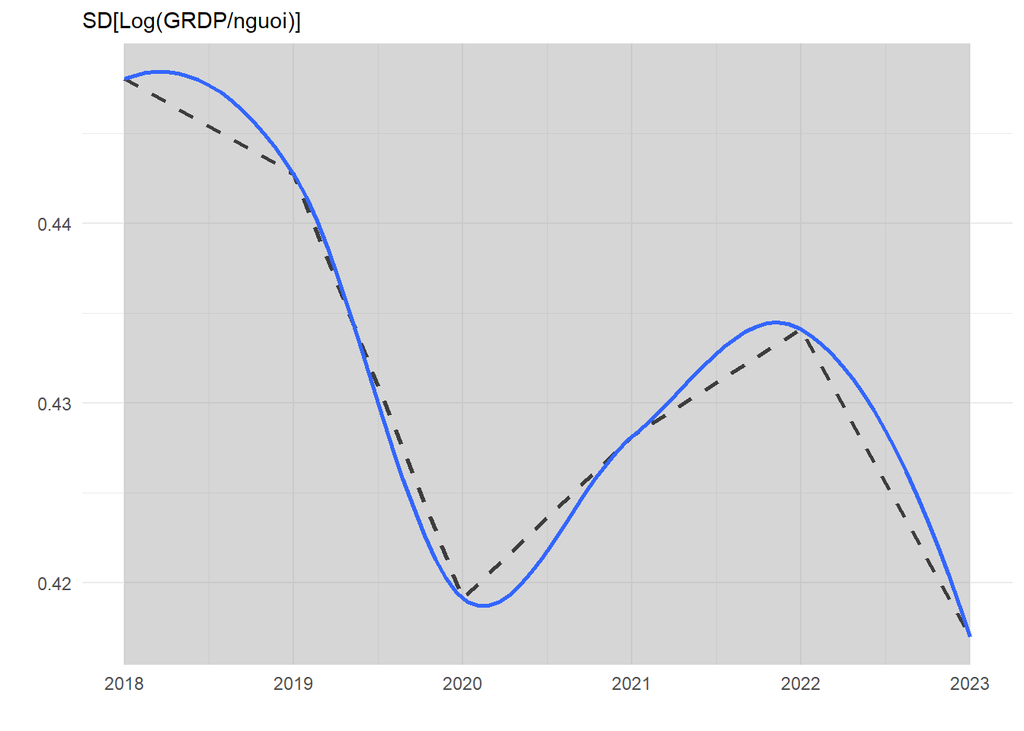

```r
sigma_trend_sd_log[["sigma.trend"]] %>%
  ggplot(aes(x = years, y = sigma.years)) +
  geom_line(size=1, linetype = "dashed") +
  geom_smooth() +
  theme_minimal() +
  labs(subtitle = "SD[Log(GRDP/nguoi)]",
       x = "",
       y = "")
```

Note: An increasing dispersion implies a lack of sigma convergence